# Why should I care about research methods?

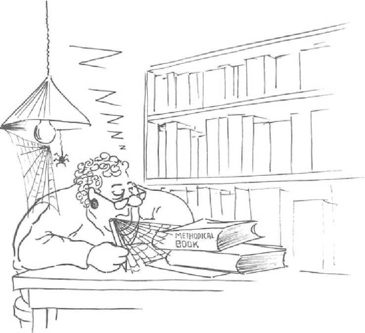

Research methods and statistics can seem like a daunting–if not completely scary–topic! This is particularly true if it is your first introduction to research. If not scary, many people tend to compare research with a snooze-fest (see above). While not everyone will share my excitement about research methods and statistics, I do think that a fundamental understanding of the basics can be applicable across whatever field of study and future career aspirations you may have.

Whatever your notions of research methods and statistics may be, my goal is to get you excited about them! While you may not reach the level of excitment I have for reasearch methods and statistics, I hope at the very least to convince you that learning some of the fundementals are important for you moving forward.

Aside from the fact that this course is required for graduation, why should you care about research methods? I think it is paramount to understand the importance of this class before we delve into the assignments and statistics. Below I highlight several potential paths that I’ve observed across a number of undergraduate students I have mentored over the years. I try to tackle some misconceptions about why research and statistics knowledge is unimportant for certain career paths, and why everyone psychology student should care about research as much as me!

## Academic Path

Regardless of what your potential future career aspirations are, if you decide to extend your training in psychology past an undergraduate degree you will encounter research and statistics again. Of course, the degree and depth of this exposure will depend on your program. For example, I spend most of my day teaching and doing research and analyses (my subfield of psychology is Social Psychology). However, my clinical psychology peers do those things in addition to seeing clients. I’ll talk about going into a “clinical” or “counseling” career path momentarily, but first let me talk about the importance of research for graduate school in general.

Descutner & Thelen (1989) surveyed faculty members at top psychology PhD programs on what they viewed as most important for incoming graduate students. They found that “Doing research” ranked number 5 on the list of most important qualities for incoming graduate students. This key area of expertise ranked ahead of qualities such as “Getting good grades”, “Creativity”, and “High intelligence”.

Further, a more recent survey of graduate students found that students rated participation in research as one of the most important factors that influenced their “preparedness for graduate school” (Huss, Randall, Patry, Davis, & Hansen, 2002).

## Clinical Sub-Path

Many psychology students are interested in being a counselor or going for a clinical PhD, focusing more on applied therapy and services rather than research. Oftentimes these students erroneously think that because they want to pursue the clinical sub-field of psychology that they will not need statistics or research methods. FALSE! As I mentioned in my Welcome, I started my graduate career as a Clinical Psychology student. Aside from the fact that one of the required courses for that major was “Research Design and Statistics”, a large part of my clinical training was reading and evaluating scientific research articles on cutting-edge research and therapies. Having a foundational understanding of research methods and statistics allowed me to critically evaluated whether or not research on specific types of therapy or interventions was reliable and valid ( which we will talk about later in the course). Additionally, knowing about research methods and statistics was essential for successfully communicating with my colleagues and clients the information I learned.

Oh, and the survey I mentioned above? It was a survey of faculty at Clinical PhD programs. Even within clinical programs research experience is weighed heavily as an important skill for incoming graduate students! In short, do not underestimate the importance of research and statistics knowledge for your future academic careers!

## Industry Path

Research and statistics is important for industry, too, just like academia or clinical services. Hart Research Associates conducted a [survey](https://www.aacu.org/publications-research/periodicals/it-takes-more-major-employer-priorities-college-learning-and) of over 300 employers to ask them what was important for new hires. Guess what? One of the key findings from the survey was that employers value cross-cutting knowledge, including research (Hart Research Associates, 2013)!

> Employers endorse several educational practices as potentially helpful in preparing college students for workplace success. These include practices that require students to conduct research and use evidence-based analysis; gain in-depth knowledge in the major and analytic, problem-solving, and communication skills; and apply their learning in real-world settings.

There are several questions the researchers asked that had respondents highlighting the usefulness of research experience in helping undergraduate students prepare for the workplace. This is further corroborated by findings that suggest that experiences related to research and research methods are a highly desirable skills across multiple occupational fields (Burrus, Jackson, Xi, & Steinberg, 2013).

A quick personal anecdote on the importance of research knowledge across fields: Two of my most recent undergraduate research assistants (RAs) graduated and took jobs in industry. They had both worked with me for three years doing typical RA duties such as running participants, data entry, stimulus gathering and manipulation. They also took the opportunity to participate in local research conferences presenting their own data to peers and faculty.

Having mentored them and worked with them, I was a job reference for both of these students. When I got calls from potential employers the thing they were most impressed with was the amount of research they did the and knowledge they had about social science research methods. This allowed me to talk about each students’ success at being able to critically think about issues with a scientific mindset, independently perform research tasks successfully, and their ability to generate valuable insight and questions–all of which were skills that they learned by taking a class such as this, and applying the knowledge with hands-on experience in our lab!

# Conclusions

In short, I believe that understanding basic research methods and statistics can be beneficial to anyone–whether you plan on staying in academia or continuing on for an advanced degree, or if you plan to do something in private business (HR, data analysis) or industry. Graduate admissions people and businesses alike value that types of critical thinking and applied knowledge that are inherent in fully understanding psychological and/or behavioral research methods.

Aside from taking this course, you can further your research experience by joining a lab (check out the World Campus online research lab!), or volunteering at a local university helping a faculty member with their research!

# References

Burrus, J., Jackson, T., Xi, N., & Steinberg, J. (2013). Identifying the most important 21st century workforce competencies: An analysis of the occupational information network (o* net). *ETS Research Report Series*, *2013*(2), i–55. Wiley Online Library.

Descutner, C. J., & Thelen, M. H. (1989). Graduate student and faculty perspectives about graduate school. *Teaching of Psychology*, *16*(2), 58–61. SAGE Publications Sage CA: Los Angeles, CA.

Hart Research Associates. (2013). It takes more than a major: Employer priorities for college learning and student success. Retrieved from https://www.aacu.org/publications-research/periodicals/it-takes-more-major-employer-priorities-college-learning-and

Huss, M. T., Randall, B. A., Patry, M., Davis, S. F., & Hansen, D. J. (2002). Factors influencing self-rated preparedness for graduate school: A survey of graduate students. *Teaching of Psychology*, *29*(4), 275–281. SAGE Publications Sage CA: Los Angeles, CA.